# Badanie ryzyka rynkowego i analiza VaR dla indeksów giełdowych NASDAQ100, RUSSELL2000 oraz NYSE Composite na podstawie danych dziennych z lat 2016-2021

## Korelacje i autokorelacje

Aby sprawdzić hipoteze postawioną we wstępie, należy policzyc współczynniki korelacji liniowej między wartościami stóp zwrotu.

Do tego na wykresie zaprezentowano także autokorelacje.

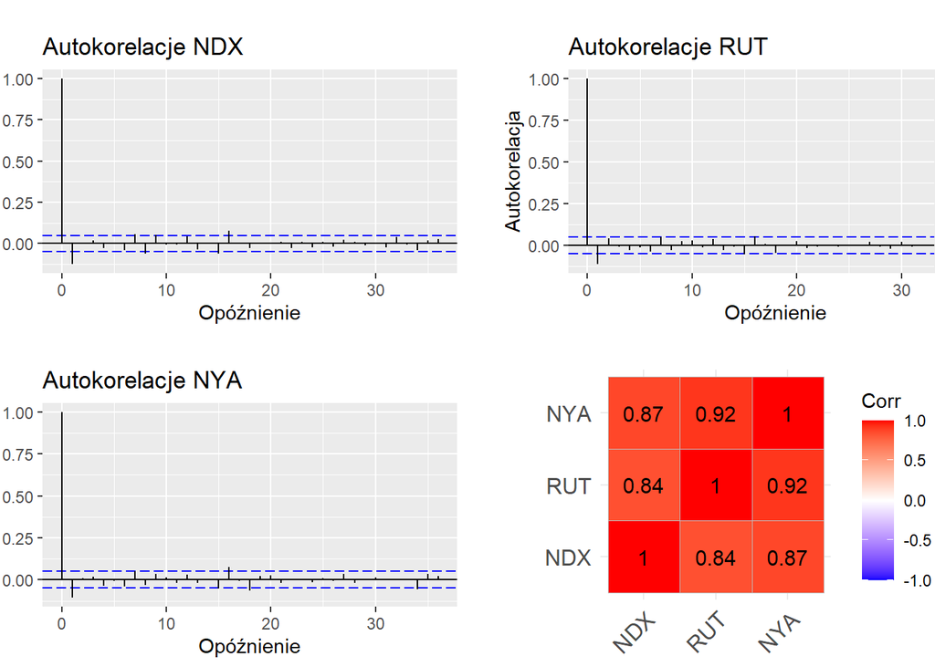

Widać, że zgodnie z przypuszczeniami, między stopami zwrotu indeksów zachodzi silna korelacja.

Oprócz tego, widac, że każdy z badanych indeksów wykazuje istotną na poziomie 5%, autokorelacje 1 rzędu. Wartości autokorelacji są ujemne i niewielkie, co nakazuje sądzić, że z dnia na dzień można się spodziewać na zmianę stopy zwrotu ujemnej i dodatniej. Autokorelacja jednak jest niska, więc wniosek ten nie jest pewny.

# Analiza ryzyka

Po przebadaniu jakimi własnościami charakteryzują się stopy zwrotu dla badanych indeksów, można przejść do wyznaczania wartości VaR (wartości narażonej na ryzyko) oraz ES (warunkowej wartości narazonej na ryzyko).

Wartości VaR i ES zostaną wyznaczone na poziomach 95% i 99%, przy użyciu 4 metod.

- Metody historycznej
- Metody historycznej z wagami
- Metody symulacyjnej Monte Carlo
- Metody uwzględniającej heteroskedastyczność - przy pomocy zmienności obliczonej modelem EWMA z parametrem lambda = 0.99

## Wyznaczanie VaR i ES

Przed wyznaczeniem wartości VaR i ES, warto pojrzeć, jak w czasie zmieniały się rozkłady stóp zwrotu indeksów w podziale na lata.

Warto także zaznaczyć, że przy wyznaczaniu wartości VaR i ES przyjęto długość okna T=250.

Ze względu na powyższe, pierwsza wartość VaR, wyznaczona jest więc na dzień 03/01/2007

[figure not shown]

Na wykresie widać mniej więcej rówanież, że rozkłady z okresów kryzysów gospodarczych sa znacznie bardziej spłaszczone. Poza tym widać, że w latach bez kryzysów i krachów, rozkłady dziennych stóp zwrotu w podziale rocznym pozostają mniej więcej takie same.

Na podstawie tych wykresów, spodziewamy się więc skoków VaR i ES w latach w których rozkłady zaczynaja być rozciągnięte, gdyz automatycznie najczarniejszy scenariusz będzie polem pod szerzej rozciągniętym i spłaszczonym końcem lewego ogonu rozkładu. Zatem spodziewamy się skoków VaR i ES wtedy, kiedy na świecie był kryzys gospodarczy.

## VaR i ES 99%

### Metoda symulacji historycznych

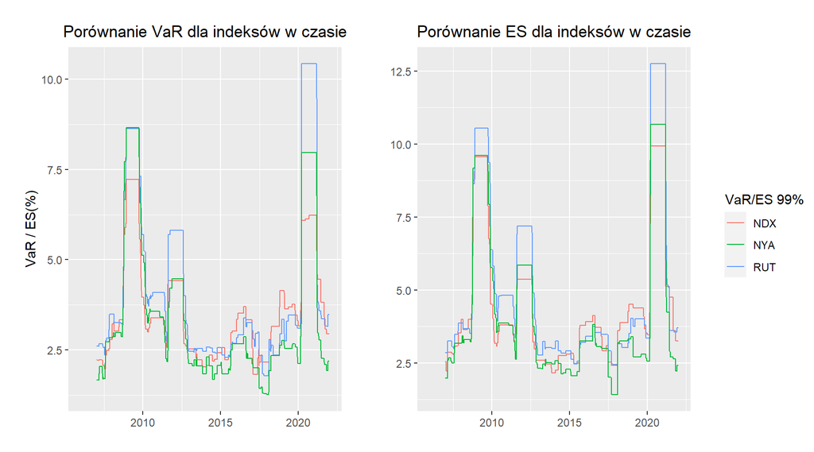

W przypadku metody historycznej, spodziewane skoki pojawiły się w odpowiednich momentach. W dodatku wartośći VaR i ES, są stosunkowo niskie, co nakazuje sądzić, że inwestowanie w powyższe indeksy, nie jest obarczone dużym ryzykiem, ani dużą strata kapitału. Dla 99% VaR, największą wartością było ponad 10% w roku 2020, wtedy też wartość ES wynosiła ponad 12.5% kapitału wkładowego.

### Metoda symulacji historycznych z wagami

W przypadku zastosowania metody historycznej z uwzględnieniem wag, piki pojawiają się w tych samych miejscach jednak znacznie szybciej maleją.

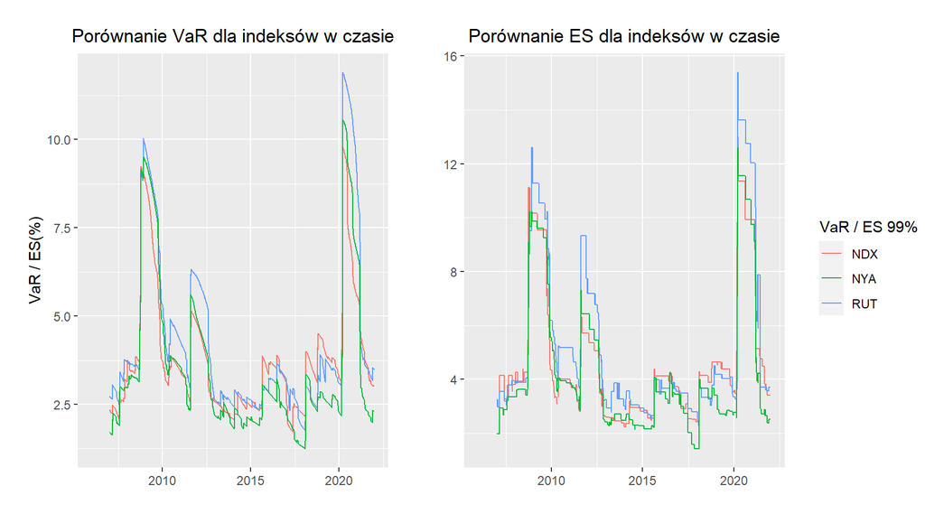

### Metoda monte carlo

Stosując metodę Monte Carlo, przyjmuję założenie o normalności rozkłądu stóp zwrotu. W związku z tym, że łącznie stopy zwrotu takiego rozkładu nie mają, można podejrzewać, że VaR i ES wyznaczone ta metodą nie będą wiarygodne.

Na poniższym wykresie widac, że przez losowanie w każdym dniu nowego rozkładu, powstały wahania o wysokiej częstotliwości. Należy równiez zwrócić uwagę, że przez zastosowanie rozkładu normalnego, wartości VaR nie są daleko odległe od wartości ES, w przeciwieństwie do poprzednich metod.

Dzieje się tak ze względu na to, że w danych empirycznych występowało dużo wartości odstających, a w przypadku rozkładu normalnego, zgodnie z regułą 3 sigm, nie ma dużo wartości mocno odstających od średniej.

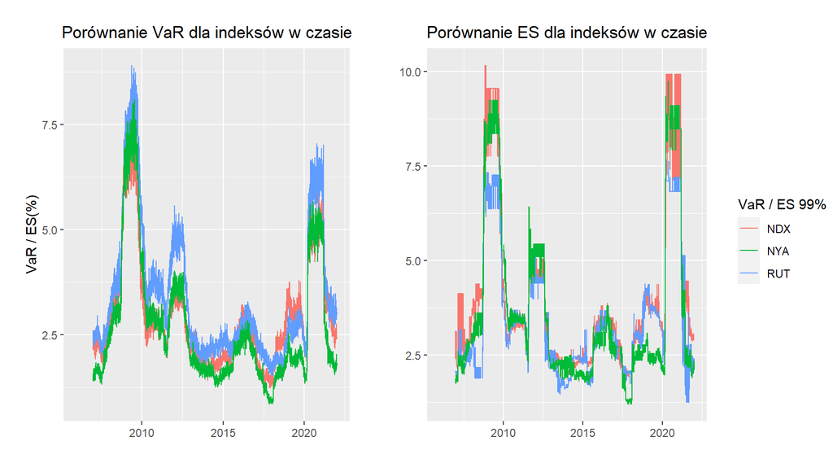

### Metoda EWMA

Przez zastosowanie wysokiej wartości lambda przy modelowaniu zmienności, model dłużej pamięta starsze obserwacje. powoduje to, że wykres VaR i ES upodabnia się do tego uzyskanego metoda historyczną.

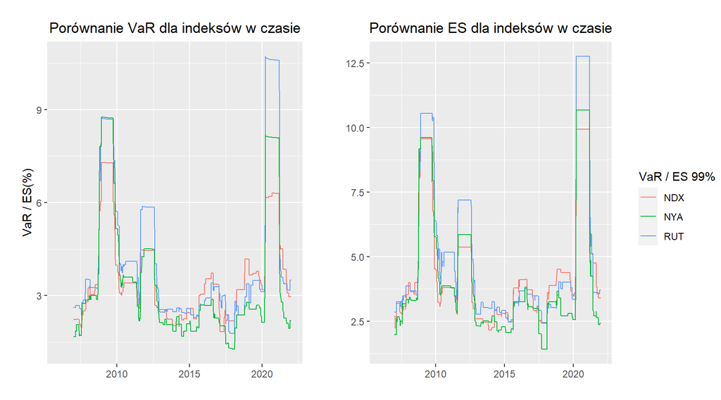

### Porównanie uzyskanych wyników

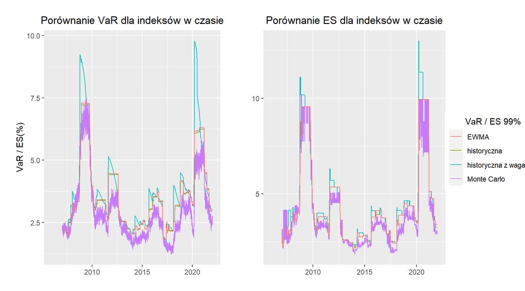

Na powyższym wykresie można zobaczyć zestawienie wyników.

Widać, że w zdecydowanej większości wykresy mniej lub bardziej się na siebie nakładają. Najwieksze różnice można zobaczyć przy pikach. Zdecydowanie najwyżej rosną wartości VaR i ES uzyskane metoda historyczną z wagami.

Spadaja one jednak zdecydowanie szybciej niż VaR i ES obliczony pozostałymi metodami.

Na poniższych wykresach z kolei można zobaczyć, jak wyglądają wartości VaR i ES dla poziomu 99% w podziale na indeks i metody

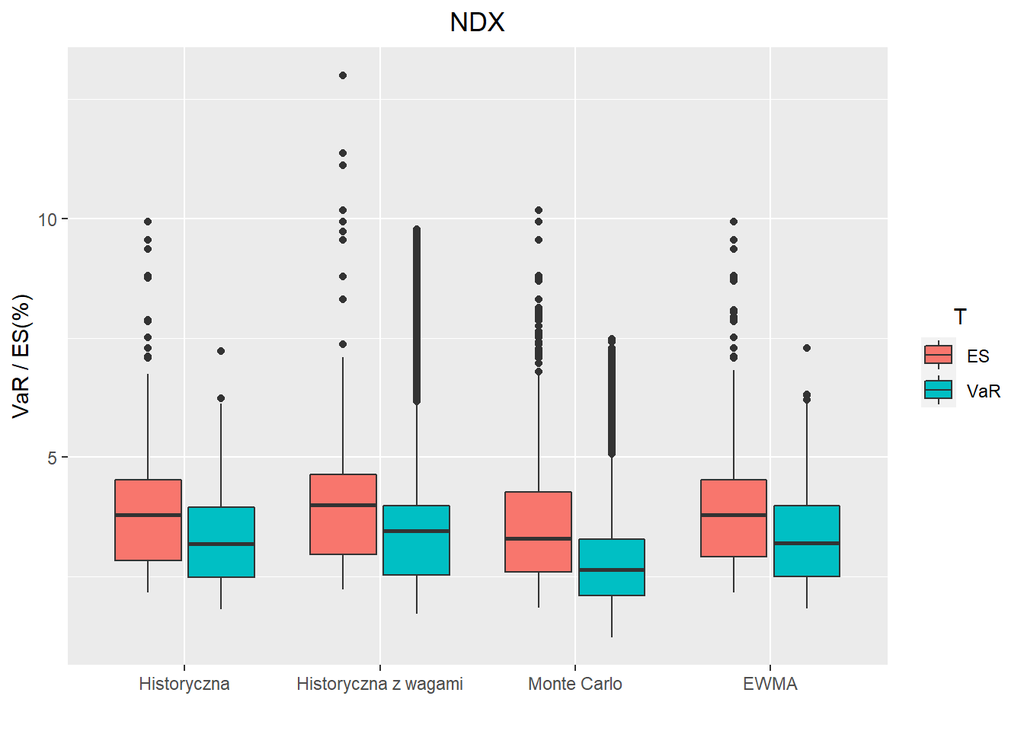

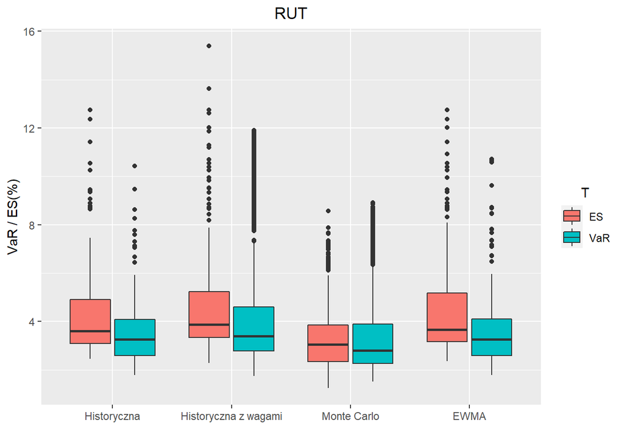

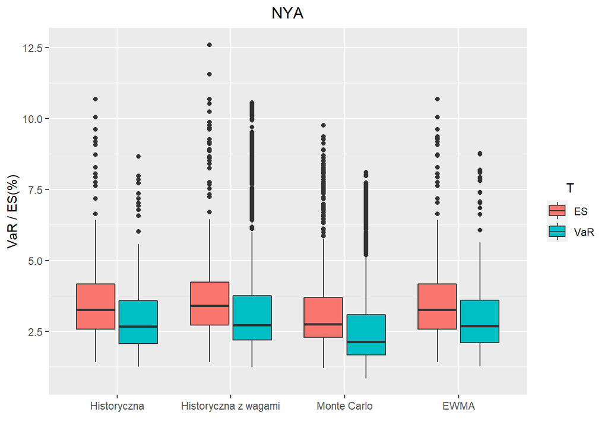

Na wykresach widac między innymi, ze właśnie metoda historyczna z wagami daje najwyższe wartości 99% VaR i ES w przypadku każdego indeksu.

Z kolei metoda monte Carlo daje zdecydowanie najniżne wartości ES i VaR ze względu na jej wahania.

Warto zwrócic też uwage na wspomnianą wcześniej własciwość - wartości uzyskane metodami z użyciem EWMA oraz historyczną, wykazują co do zasady praktycznie takie same wartości.

Widać także, że średnie wartości VaR, dla każdego indeksu utrzymują się poniżej wartości 5%. Dla indeksu NYA, średnia wartość 99% vaR to tylko około 2.5%, co uwzględniając jedynie VaR i ES, czyni go to najbezpieczniejszą inwestycją z powyższych indeksów.

## VaR i ES 95%

Poniżej przedstawione zostaną wartości VaR i ES obliczone tymi samymi metodami co powyżej, ale tym razem dla poziomu 95%

### Metoda symulacji historycznych

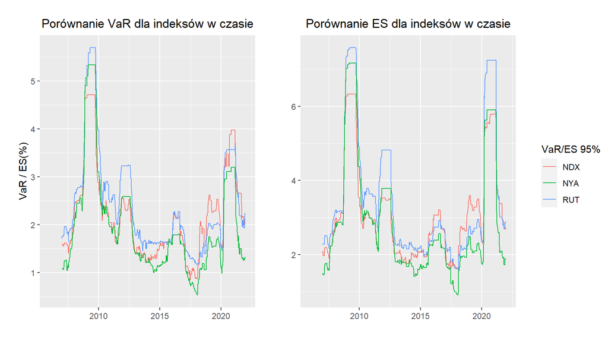

Oczywistym i spodziewanym rezultatem obniżenia wartości VaR z 99% do 95% jest zmniejszenie wartości osiąganych przez VaR i ES. Wizualnie jednak wykresy pozostają w tym samym kształcie, a piki są w tych samych miejscach co w przypadku VaR i ES 99%.

Poniżej pozostałe metody.

### Metoda symulacji historycznych z wagami

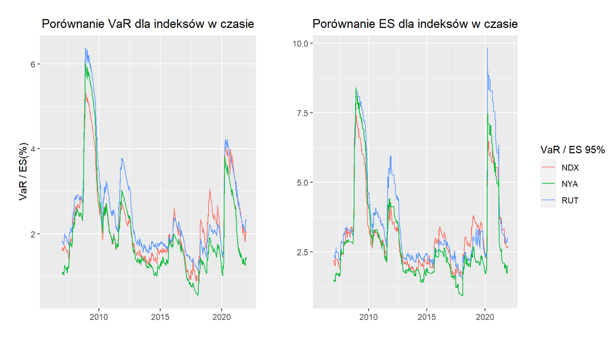

### Metoda monte carlo

Stosując metodę Monte Carlo, przyjmuję założenie o normalności rozkłądu stóp zwrotu. W związku z tym, że łącznie stopy zwrotu takiego rozkładu nie mają, można podejrzewać, że VaR i ES wyznaczone ta metodą nie będą wiarygodne.

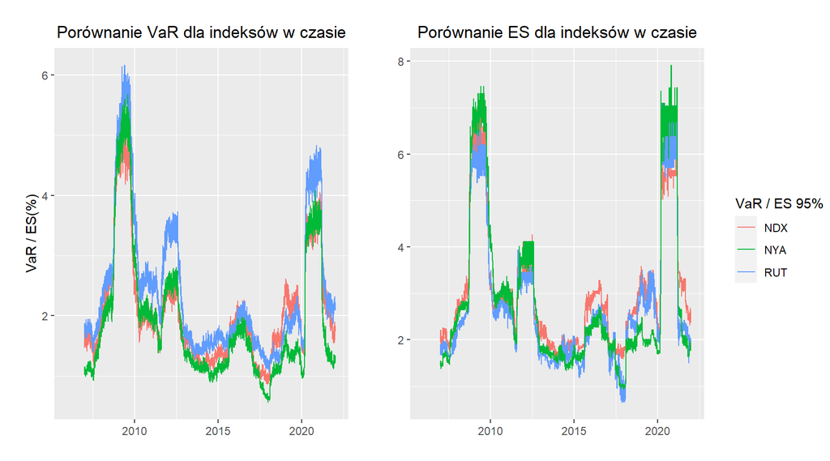

### Metoda EWMA

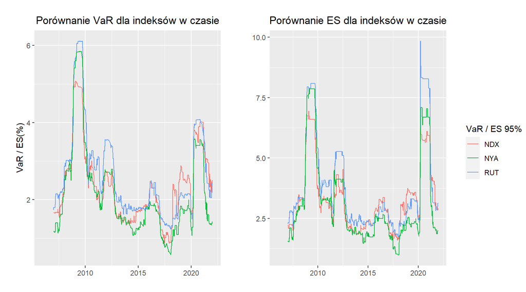

### Porównanie uzyskanych wyników

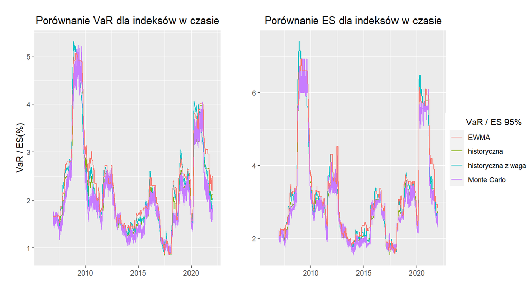

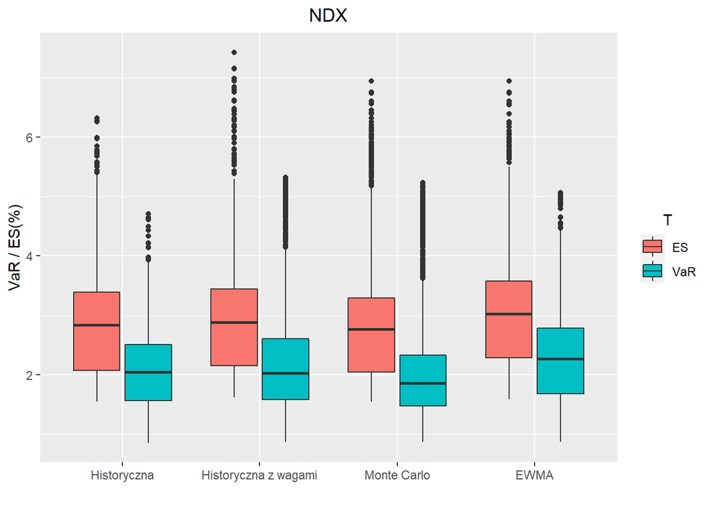

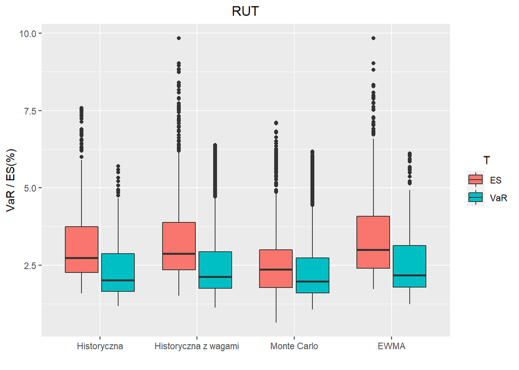

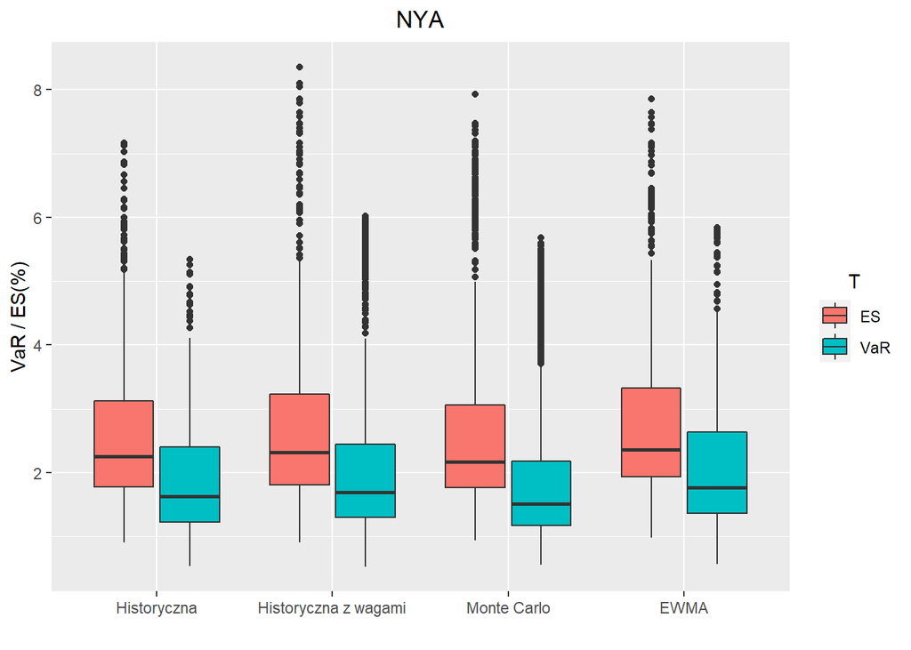

Na powyższych wykresach widać, że wartości VaR i ES 95% mają te same własności co VaR i ES 99%, różnia się jedynie zakresem osiąganych wartości.

Wartości z kolei, naturalnie są niższe przez obniżenie poziomu VaR i ES. Pozostałe wnioski pozostają takie same.

## Testy wsteczne

W celu sprawddzenia, jak dokładnie obliczone wartości VaR wpisują się w wartości rzeczywiste, wykonane zostaną 3 testy wsteczne:

- Test Kupca - sprawdzający poprawność VaR
- Test DQ - sprawdzający poprawność VaR
- Test Christoffesena - test niezależności przekroczeń VaR w czasie

W tabelach poniżej zawarte zostały wartości procentowe akceptacji hipotez zerowych w odpowiednich testach.

### VaR 99%

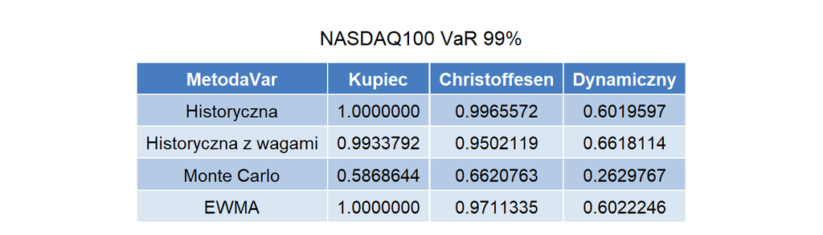

VaRy 99% wyznaczne metodą historyczną, historyczną z wagami oraz przy użyciu modelu EWMA, nie róznią się znacznie w procencie akceptowanych wyników. Znacznie odstaje natomiast metoda Monte carlo. Prawdopodobnie dzieje się tak ze względu na brak normalności rozkładu stóp procentowych.

Warty uwagi jest również fakt, że test DQ akceptuje VaR w znacznie mniejszym niż test kupca. Biorąc pod uwagę łączną ilość akceptacji hipotez zerowych, najlepszą metoda dla wyznaczenia 99% VaR dla NASDAQ100 okazuje się być metoda historyczna z wagami, jedynie o kilka akceptacji wyprzedzająca metodę historyczną.

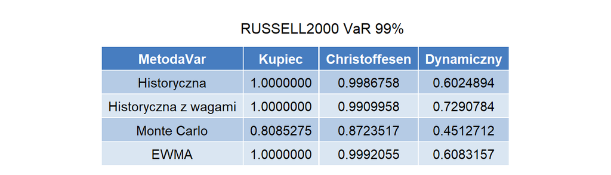

W przypadku indeksu RUT, można zaobserwować to samo co w przypadku NDX, czyli że VaR metodą monte carlo jest wyznaczony zdecydowanie gorzej od metod pozostałych.

Biorąc pod uwagę łączną ilość akceptacji hipotez zerowych, najlepszą metoda dla wyznaczenia 99% VaR dla RUSSELL2000 okazuje się być metoda historyczna z wagami.

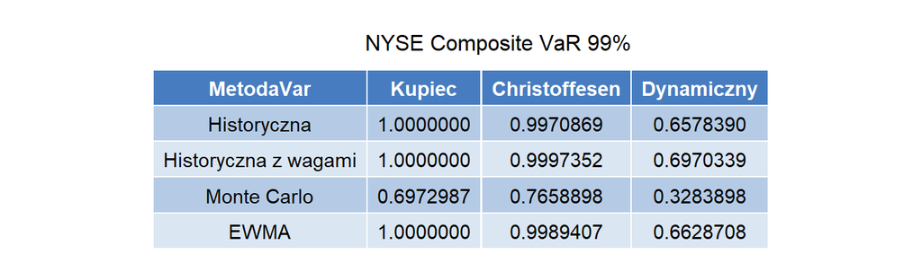

W przypadku NYSE, wszystkie metody, za wyjątkiem monte carlo, znów dają wysoki procent akceptacji.

Najlepszą metodą okazała się być metoda historyczna z wagami. Warto też wspomnieć, że dla wszystkich indeksów 99% VaR, wyznaczoany metodami: historyczna i przy pomocy zmienności z moedelm EWMA, jest akceptowany na całej długości okna czasowego przez test kupca.

### Var 95%

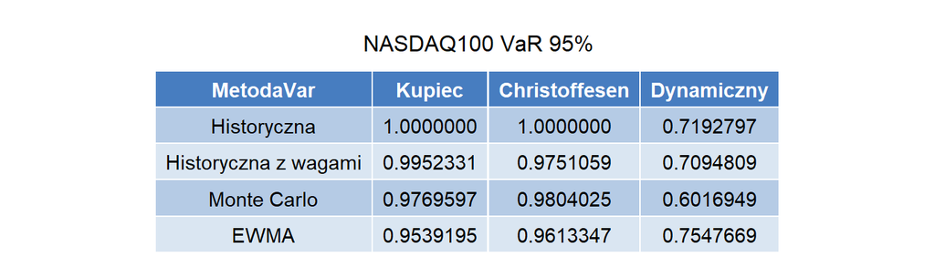

W przypadku dokładności 95% VaR dla NASDAQ100, obserwujemy, że metoda monte carlo zaczęła byc akceptowana przez testy znacznie więcej razy.

Łącznie akceptującą najwięcej wyznaczonych VaRów, uwzględniając wszystkie testy, znów okazała się metoda historyczna.

Najlepsze wyniki dal pozostałych indeksów można odczytać z poniższych tabel.

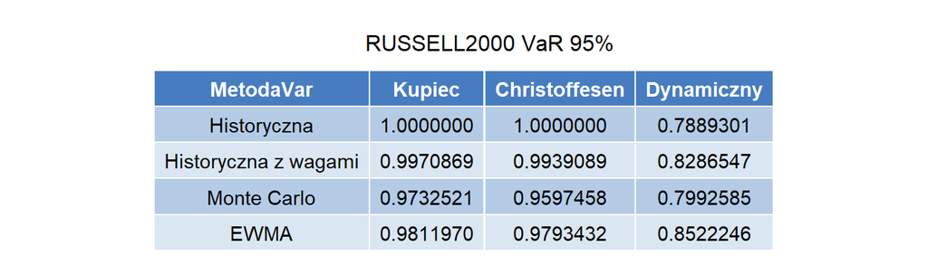

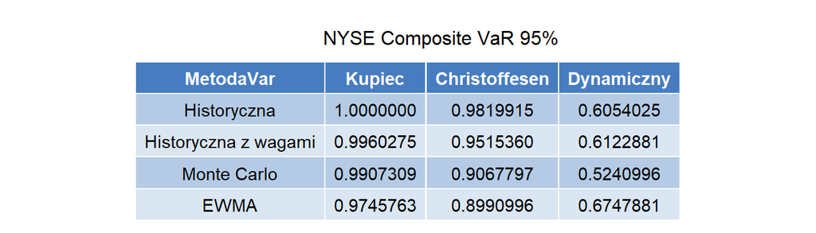

# Podusmowanie

Po analizie, na mocy przeprowadzonych testów wstecznych oraz analiz, mozna wybrać najlepsze metody wyznaczania VaR 99% i 95%.

W poniższej tabeli można zobaczyć zestawienie:

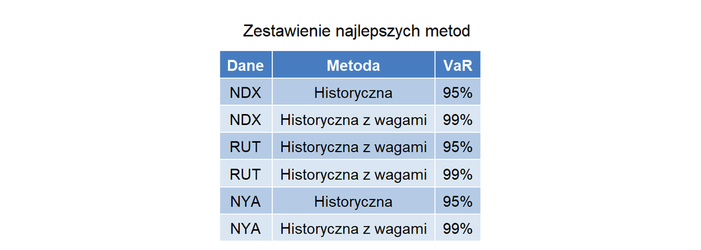

Warte wspomnienia, jest także to, że kiedy test Christoffensena akceptuje 100% wyznacoznych VaRów, znaczy to, że przekroczenia są w dal wszystkich VaRów niezalezne w czasie - co za tym idzie, VaR nie jest odporny tylko na wahania i spadki losowe jak kryzysy czy krachy na giedłdzie.

Podsumowując, na podstawie uzyskanych wartości VaR i ES, można stwierdzić, że inwestycje w indexy sa mało ryzykowne. Najbezpieczniejszym - najmniej ryzykownym, okazał się indeks NYA, zarówno biorąc pod uwagę VaR 99% i 95%. Można też powiedzieć, że dla NYSE Composite, zaobserwowano mały procent odrzuceń wartości VaR przez zastosowanie testów wstecznych. Umacnie to tylko stwierdzenie, że NYSE jest indeksem stabilnym.